# act_report

## Report: act_report

The dataset is about the prediction of dogs rating and breed on the twitter platform.After a successful wrangling and cleaning of the data was stored in a master dataset, i analyzed and visualized it. In the process of analyzing the twitter archive master dataset, three insight were discovered and visualized.

#### Note: the codes provided below are meant to help visualize the insights

```python
# i imported some libraries for the visualization of the dataset
import pandas as pd
import seaborn as sb
import matplotlib.pyplot as plt
```

```python
# i imported the dataset into the notebook
dog_viz = pd.read_csv('twitter_archive_master.csv')
```

### Insights:

1. the relationship between the favorite_count and retweet_count
2. the most popular dog_breed
3. checking the dog_breed with the highest ratings

### first insight

- i analysed the relationship between the favorite_count and the retweet_count. i made use of seaborn to visualize this it is dicovered that theyre both correlated and have a positive relationship between them. even though they are both clustered at the beginning. it is visualized below

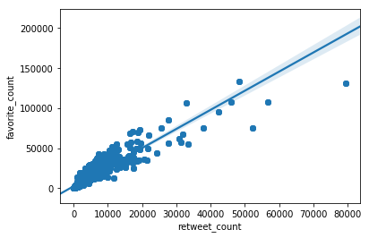

```python
sb.regplot( dog_viz.retweet_count, dog_viz.favorite_count, data = dog_viz, fit_reg = True, x_jitter =0.3);
```

### second insight

- i checked for the most popular dog_breed.

i calculated the dog_breed count and computed their individual mean for twenty dog_breed as this is just a sample from the total population. it can be seen that the golden retriever is the most popular dog_breed in the visual below

```python
# this was to get the breed counts and average value of the sample needed
dogbreed_counts=dog_viz.dog_breeds.value_counts()#[:20]
dog_rate=dog_viz.groupby(['dog_breeds'])['rating_numerator'].mean()#.nlargest(n=20, keep='first')
count_rates=dog_rate/dogbreed_counts
count_rates.nsmallest(n=20, keep='first')
```

```
Unknown                     0.013757
golden_retriever            0.019518
Chihuahua                   0.029167
Pembroke                    0.030387
Labrador_retriever          0.032285
pug                         0.041298
toy_poodle                  0.055000
Samoyed                     0.069586
chow                        0.073785
Pomeranian                  0.076443
malamute                    0.082415
Chesapeake_Bay_retriever    0.087409
French_bulldog              0.090271
cocker_spaniel              0.094444
miniature_pinscher          0.104601
Maltese_dog                 0.122576
beagle                      0.126875
Shih-Tzu                    0.129375
Eskimo_dog                  0.129649
German_shepherd             0.130952
dtype: float64
```

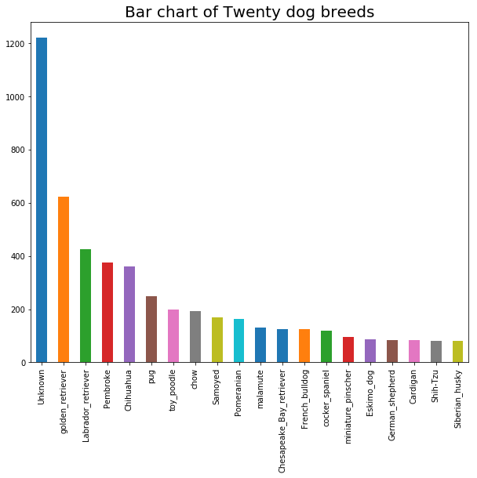

```python
plt.figure(figsize=([10, 8]))
dogbreed_counts[:20].plot(kind='bar')
plt.title('Bar chart of Twenty dog breeds', fontsize=20);
```

### third insight

1. checking the dog_breed with the highest ratings.

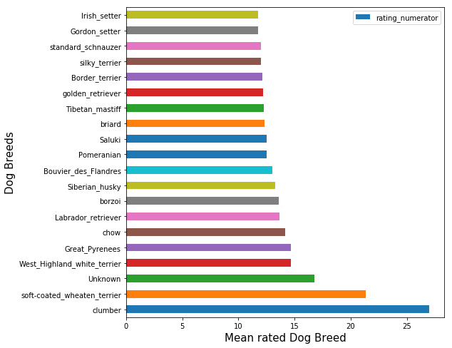

```python
plt.figure(figsize=(8, 8))
dog_rate.nlargest(n=20, keep='first').plot(kind= 'barh', legend=True)
plt.ylabel('Dog Breeds', fontsize=15)
plt.xlabel('Mean rated Dog Breed',fontsize=15);
```